# Prediction Assignment Writeup

Luciano Lattes

March 10, 2016

# Assignment goal

The main objective of this assignment is predicting the manner in which a series of people did a weight lifting exercise based on data collected from accelerometers on the belt, forearm, arm, and dumbell.

To achieve the mentioned goal, we will *tidy our data*, *train a prediction model* and use that model to *predict 20 different test cases*.

# Model training

For this prediction assignment, we’ll use **dplyr** and **caret** libraries so let’s load them first:

```r
setwd("~/Projects/practical-ml-assignment")

library(dplyr)
library(caret)
```

Then, we need to ingest the data into R. For that purpose, we use `read.csv` with some custom options to avoid problems in the resulting `data.frame`:

```r
training <- read.csv("pml-training.csv", stringsAsFactors = FALSE, dec = ".", numerals = "allow.loss")
# Check the possible values of the outcome variable and the participants
unique(training$classe)
unique(training$user_name)
# Check the dimensions of our data.frame
dim(training)
```

```
## [1] "A" "B" "C" "D" "E"
## [1] "carlitos" "pedro"    "adelmo"   "charles"  "eurico"   "jeremy"
## [1] 19622   160
```

For tidying our data we need to transform several character variables, like `classe`, `user_name` and `new_window`, into factors and also transform the numerical variables that were coerced to characters into numeric.

```r
training$user_name <- as.factor(training$user_name)
training$classe <- as.factor(training$classe)
training$new_window <- as.factor(training$new_window)

# Check which columns related to accelerometer data are still character and coerce to numeric
character_cols <- which(sapply(training, is.character))
for (i in character_cols) {
  if (i >= 12 & i < 160) {
    training[, i] <- as.numeric(training[, i])
  }
}
```

The remaining `character` column is `cvtd_timestamp`. We will split that feature into 5 new columns (year, month, day, hour, minutes):

```r
training$cvtd_timestamp <- as.POSIXct(training$cvtd_timestamp, format = "%d/%m/%Y %H:%M", tz = "UTC")
training$timestamp_year <- as.integer(format(training$cvtd_timestamp, "%Y"))
training$timestamp_month <- as.integer(format(training$cvtd_timestamp, "%m"))
training$timestamp_day <- as.integer(format(training$cvtd_timestamp, "%d"))
training$timestamp_hour <- as.integer(format(training$cvtd_timestamp, "%H"))
training$timestamp_minutes <- as.integer(format(training$cvtd_timestamp, "%M"))
```

Finally, we’ll remove two unnecessary predictors and replace all NAs in numeric predictors by zeroes:

```r
training <- training %>% select(-X, -cvtd_timestamp)
# There are many NAs in numeric columns, following function will return TRUE if any
sapply(training, function (x) {any(is.na(x))})
```

[output not shown]

[output cut: 55 more lines]

[output not shown]

```r
training[is.na(training)] <- 0 # Not so many NAs anymore!
```

Now that the training data is tidy enough, we’ll create a data partition for training and testing our model. We’ll use the **80/20** rule of thumb for the partition:

```r
set.seed(123)
to_train <- createDataPartition(y = training$classe, p = 0.8, list = FALSE)
training_set <- training[to_train, ]
testing_set <- training[-to_train, ]
# Check the dimensions of both sets
dim(training_set)
```

```
## [1] 15699   163
```

```r
dim(testing_set)
```

```
## [1] 3923  163
```

```r
# And see if the split based on the outcome (classe) has reasonable proportions
summary(training_set$classe)
```

```
##    A    B    C    D    E
## 4464 3038 2738 2573 2886
```

```r
summary(testing_set$classe)
```

```
##    A    B    C    D    E
## 1116  759  684  643  721
```

Seems we have a good split. Classes `A` and `B` have more occurrences than the other outcomes in both sets and the proportions seem similar. Now we’re leaving `testing_set` **alone for a while**, we’ll train our model relying only in `training_set` and we’ll come back to our `testing_set` later to validate the accuracy of the resulting model.

For training our model, we’ll tell `caret` to perform a K-Fold cross validation. We’ll break `training_set` into 5 subsets. The choice of 5 is somewhat arbitrary, the attempt is to take the bias-variance tradeoff into account and also avoid very high computational times.

```r
# Train using 500 trees and 5-Fold CV
random_forest <- train(classe ~ ., data = training_set, method = "rf",
                       prox = TRUE, ntree = 500, do.trace = TRUE, allowParallel = TRUE,
                       trControl = trainControl(method = "cv", number = 5))
```

Let’s take a look at the resulting model:

```r
# Check the accuracy of the trained final model by looking at its confusion matrix
print(random_forest$finalModel$confusion)
```

```
##      A    B    C    D    E  class.error
## A 4464    0    0    0    0 0.0000000000
## B    1 3036    1    0    0 0.0006583278
## C    0    2 2735    1    0 0.0010956903
## D    0    0    2 2570    1 0.0011659541
## E    0    0    0    1 2885 0.0003465003
```

It seems, based on the confusion matrix, that the classification errors for our trained model are very low, which is great!

Remind our `testing_set` data frame? Now we can use it for validating the results of our trained model:

```r
# We use the predict function with our model as first parameter and the testing_set
predictions_testing_set <- predict(random_forest, testing_set)
testing_set$right_predictions <- predictions_testing_set == testing_set$classe
table(predictions_testing_set, testing_set$classe)
```

```
##
## predictions_testing_set    A    B    C    D    E
##                       A 1116    1    0    0    0
##                       B    0  758    0    0    0
##                       C    0    0  684    1    0
##                       D    0    0    0  642    0
##                       E    0    0    0    0  721
```

We only had **2** classification errors out of 3923 cases! Seems we DO have a great model for predicting over the 20 different test cases.

Let’s plot the results so we can get a better sense of the accuracy of our model:

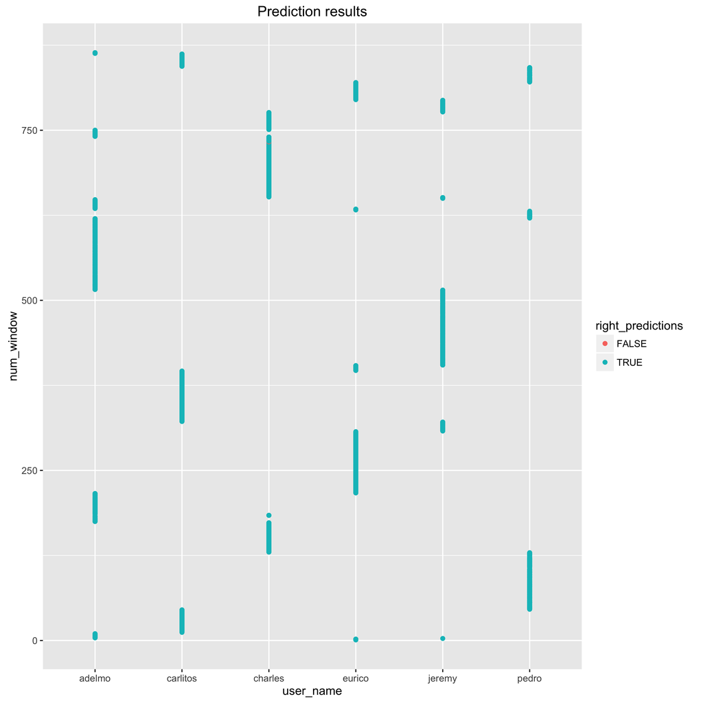

```r
# Plot num_window for each user colouring the dots according to the rightness of predictions
qplot(user_name, num_window, colour = right_predictions, data = testing_set, main="Prediction results")
```

# Predicting over the 20 testing cases

We need to do the same kind of data tidying we did for the training data, this time with `pml-testing.csv`:

```r
testing <- read.csv("pml-testing.csv", stringsAsFactors = FALSE, dec = ".", numerals = "allow.loss")
testing$user_name <- as.factor(testing$user_name)
testing$new_window <- factor(testing$new_window, levels = c("no", "yes"))

test_character_cols <- which(sapply(testing, is.character))
test_logical_cols <- which(sapply(testing, is.logical))

# This time, several all NA columns in the CSV were ingested as logical. We'll transform to numeric.
for (i in test_logical_cols) {
  testing[, i] <- as.numeric(testing[, i])
}

# Split cvtd_timestamp in year, month, day, hour, minutes
testing$cvtd_timestamp <- as.POSIXct(testing$cvtd_timestamp, format = "%d/%m/%Y %H:%M", tz = "UTC")
testing$timestamp_year <- as.integer(format(testing$cvtd_timestamp, "%Y"))
testing$timestamp_month <- as.integer(format(testing$cvtd_timestamp, "%m"))
testing$timestamp_day <- as.integer(format(testing$cvtd_timestamp, "%d"))
testing$timestamp_hour <- as.integer(format(testing$cvtd_timestamp, "%H"))
testing$timestamp_minutes <- as.integer(format(testing$cvtd_timestamp, "%M"))

testing <- testing %>% select(-X, -cvtd_timestamp)
# There are many NAs in numeric columns
sapply(testing, function (x) {any(is.na(x))})
testing[is.na(testing)] <- 0 # Removed them!
```

We’re almost there! Now we only have to predict again with our trained model, this time using the `testing` data we just cleaned-up.

```r
predictions_testing <- predict(random_forest, testing)
summary(predictions_testing)
# And the predictions are...
print(predictions_testing)
```

```
## A B C D E
## 7 8 1 1 3
##  [1] B A B A A E D B A A B C B A E E A B B B
## Levels: A B C D E
```

The results are reasonable, there are more occurrences of classes `A` and `B` than the rest, similar to what we discovered in the training data during the exploratory analysis.

We should now enter the following values `B A B A A E D B A A B C B A E E A B B B` into the **Course Project Prediction Quiz** and hope for a score better than **16**!